# 데이터분석방법론 기말과제 #1

우형진 (202085-010073)

2020-06-14

# Problem 1

*Chapter 12 Chicago Insurance Redlining- a complete example in Faraway-PRA 의 주요 기본 분석 처리를 Rstudio의 rmarkdown 을 이용하여 html(또는 pdf) 요약보고서로 간단히 정리하여 제출하기*

## Package Loading

```r
rm(list=ls())

library(faraway)
library(ggplot2)
library(gridExtra)
library(GGally)
library(reshape2)
library(ggfortify)
library(knitr)
library(dplyr)
library(kableExtra)
library(leaps)
```

## `eco` Data Loading and Analysis

```r
data(eco)
summary(eco)
```

```
##      usborn           income           home            pop
##  Min.   :0.7454   Min.   :18958   Min.   :21.80   Min.   :  453588
##  1st Qu.:0.9144   1st Qu.:21895   1st Qu.:50.40   1st Qu.: 1214880
##  Median :0.9621   Median :24957   Median :64.70   Median : 3294394
##  Mean   :0.9403   Mean   :25370   Mean   :60.84   Mean   : 4876664
##  3rd Qu.:0.9781   3rd Qu.:27444   3rd Qu.:70.75   3rd Qu.: 5780292
##  Max.   :0.9899   Max.   :37598   Max.   :80.20   Max.   :29760021
```

```r
str(eco)
```

```
## 'data.frame':    51 obs. of  4 variables:
##  $ usborn: num  0.987 0.939 0.909 0.987 0.745 ...
##  $ income: num  21442 25675 23060 20346 27503 ...
##  $ home  : num  75.9 34 34.2 67.1 46.4 43.3 57 50.2 39.3 30.5 ...
##  $ pop   : num  4040587 550043 3665228 2350725 29760021 ...
```

```r
plot1 <- ggplot(data = eco, aes(x= usborn, y = income)) +
  geom_point() + xlab("Proportion US born") + ylab("Mean Annual Income") +
  theme_bw()

# 회귀모형 적합
eco_lm <- lm(income ~ usborn, data = eco)
summary(eco_lm)
```

```
##
## Call:
## lm(formula = income ~ usborn, data = eco)
##
## Residuals:
##     Min      1Q  Median      3Q     Max
## -6836.5 -2591.5   250.7  1332.1 10262.6
##
## Coefficients:
##             Estimate Std. Error t value Pr(>|t|)
## (Intercept)    68642       8739   7.855 3.19e-10 ***
## usborn        -46019       9279  -4.959 8.89e-06 ***
## ---
## Signif. codes:  0 '***' 0.001 '**' 0.01 '*' 0.05 '.' 0.1 ' ' 1
##
## Residual standard error: 3490 on 49 degrees of freedom
## Multiple R-squared:  0.3342, Adjusted R-squared:  0.3206
## F-statistic:  24.6 on 1 and 49 DF,  p-value: 8.891e-06
```

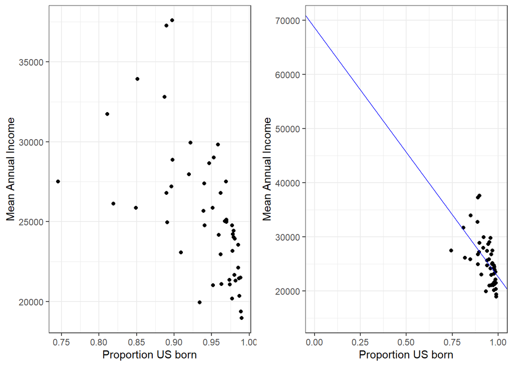

```r
# x축 확대 및 회귀식 표현
plot2 <- plot1 +
  geom_abline(slope = eco_lm$coef[2], intercept = eco_lm$coef[1], col = "blue") +
  coord_cartesian(xlim = c(0, 1), ylim = c(15000, 70000))

grid.arrange(plot1, plot2, ncol = 2)
```

`eco` 데이터셋에 대한 기본적인 회귀분석 결과, 설명변수 `usborn`이 통계적으로 유의하고, 산점도 및 x 축을 확장한 산점도에 회귀식을 추가표현한 산점를 통해 확인할 수 있듯이, `usborn`과 종속변수 `income`이 음의 상관관계가 존재함을 확인할 수 있다.

상기 모형에서 적합된 회귀식이 $income = -46019 * usborn + 68642$ 이므로, `usborn`이 1인 경우, 즉 미국에서 태어난 경우 `income`이 46019 가량 더 낮다는 결론에 다다르나, 실제 US Bureau of the Census 의 자료에서는 미국 태생인 경우 소득이 조금 더 높다. Faraway는 이처럼 집계된 데이터로 파악한 결과가 개별 수준으로 내려갔을 때는 사실이 아닐 수 있음을 지적한다.

## `chicago` Data Loading

```r
data(chicago)
str(chicago)
```

```
## 'data.frame':    47 obs. of  7 variables:
##  $ race    : num  10 22.2 19.6 17.3 24.5 54 4.9 7.1 5.3 21.5 ...
##  $ fire    : num  6.2 9.5 10.5 7.7 8.6 34.1 11 6.9 7.3 15.1 ...
##  $ theft   : num  29 44 36 37 53 68 75 18 31 25 ...
##  $ age     : num  60.4 76.5 73.5 66.9 81.4 52.6 42.6 78.5 90.1 89.8 ...
##  $ volact  : num  5.3 3.1 4.8 5.7 5.9 4 7.9 6.9 7.6 3.1 ...
##  $ involact: num  0 0.1 1.2 0.5 0.7 0.3 0 0 0.4 1.1 ...
##  $ income  : num  11744 9323 9948 10656 9730 ...
```

```r
# volact 제거 및 income scale 조정
chicago2 <- data.frame(chicago[,1:4], involact = chicago[,6],
                       income = chicago[,7]/1000)

summary(chicago2)
```

```
##       race            fire           theft             age
##  Min.   : 1.00   Min.   : 2.00   Min.   :  3.00   Min.   : 2.00
##  1st Qu.: 3.75   1st Qu.: 5.65   1st Qu.: 22.00   1st Qu.:48.60
##  Median :24.50   Median :10.40   Median : 29.00   Median :65.00
##  Mean   :34.99   Mean   :12.28   Mean   : 32.36   Mean   :60.33
##  3rd Qu.:57.65   3rd Qu.:16.05   3rd Qu.: 38.00   3rd Qu.:77.30
##  Max.   :99.70   Max.   :39.70   Max.   :147.00   Max.   :90.10
##     involact          income
##  Min.   :0.0000   Min.   : 5.583
##  1st Qu.:0.0000   1st Qu.: 8.447
##  Median :0.4000   Median :10.694
##  Mean   :0.6149   Mean   :10.696
##  3rd Qu.:0.9000   3rd Qu.:11.989
##  Max.   :2.2000   Max.   :21.480
```

`chicago` 데이터셋을 통해 종속변수 `involact`에 대한 `race` 및 다른 설명변수의 영향을 살펴보도록 한다. 기술통계량 상에서 소수 인종의 비율인 `race`의 범위가 넓어 분석이 효과적일 것을 기대된다.

## Graphical EDA (1)

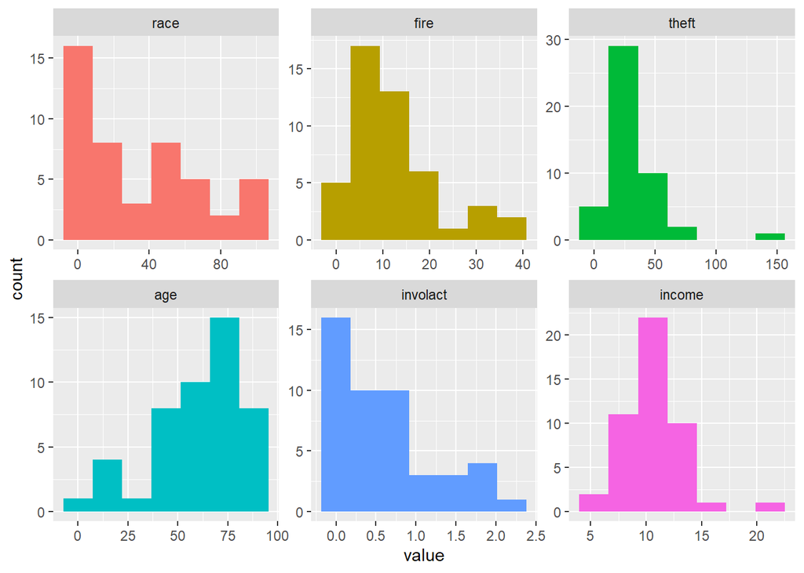

```r
# multiple histogram using reshape2 package
ggplot(data = melt(chicago2), aes(x = value, fill = variable)) +
  geom_histogram(stat = "bin", bins = 7) + facet_wrap(~ variable, scale = "free") +
  theme(legend.position = "none")
```

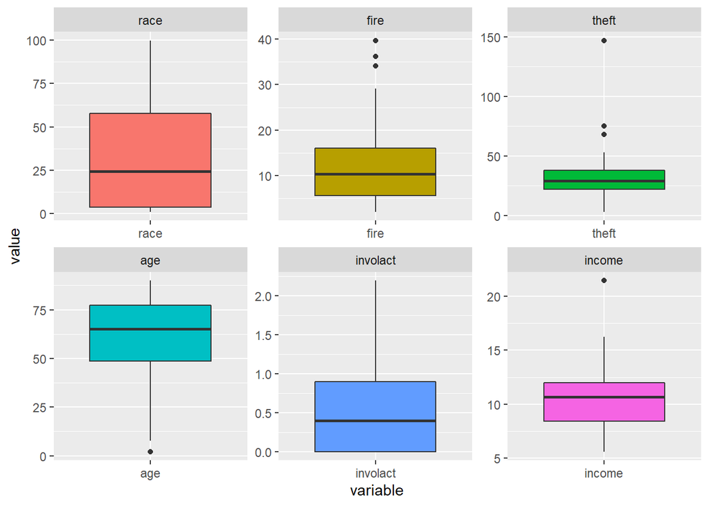

```r
# multiple boxplot using reshape2 package
ggplot(data = melt(chicago2), aes(x = variable, y = value)) +
  geom_boxplot(aes(fill = variable)) + facet_wrap(~variable, scale="free") +
  theme(legend.position = "none")
```

자료의 분포형태에 대한 EDA 결과, 종속변수인 `involact`에는 0값이 많고 치우친 형태를 보여 분석에 주의가 필요할 것으로 판단되며, `theft`와 `fire`를 비롯한 설명변수들의 분포가 고르지 않고 치우쳐 있는 것으로 보인다.

## Graphical EDA (2)

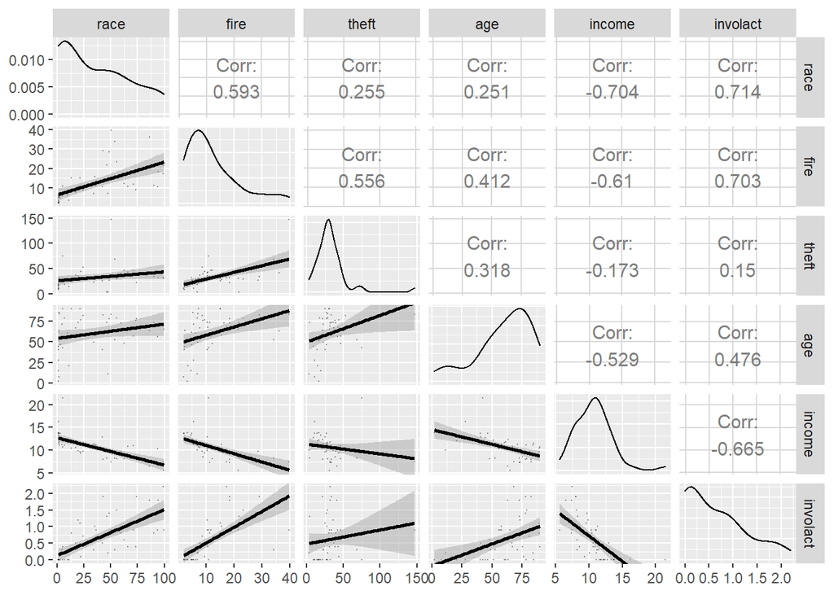

```r
# pairs
ggpairs(cbind(chicago2[,1:4], income = chicago2[,6], involact = chicago2[,5]),
        lower = list(continuous = wrap("smooth", alpha = 0.3, size = 0.1)),
        diag = list(discrete="barDiag",
                    continuous = wrap("densityDiag", alpha = 0.5 )),
        upper = list(combo = wrap("box_no_facet", alpha = 0.5),
                            continuous = wrap("cor", size = 4,
                                              alignPercent = 0.8))) +
  theme(legend.position = "bottom")
```

```r
summary(lm(involact ~ race, data = chicago2))
```

```
##
## Call:
## lm(formula = involact ~ race, data = chicago2)
##
## Residuals:
##     Min      1Q  Median      3Q     Max
## -0.7496 -0.2479 -0.1487  0.3129  1.1724
##
## Coefficients:
##             Estimate Std. Error t value Pr(>|t|)
## (Intercept) 0.129218   0.096611   1.338    0.188
## race        0.013882   0.002031   6.836 1.78e-08 ***
## ---
## Signif. codes:  0 '***' 0.001 '**' 0.01 '*' 0.05 '.' 0.1 ' ' 1
##
## Residual standard error: 0.4488 on 45 degrees of freedom
## Multiple R-squared:  0.5094, Adjusted R-squared:  0.4985
## F-statistic: 46.73 on 1 and 45 DF,  p-value: 1.784e-08
```

상관관계/산점도행렬을 확인할 수 있는 것처럼 `fire`, `theft`, `age`와 `involact` 간에는 양의 상관관계, `income`과 `involact` 간의 음의 상관관계는 일반적으로 예측할 수 있는 방향인 것으로 판단된다. 다만 `race`와 `involact` 사이에 양의 상관관계가 관측되고 있는데, 단순한 회귀모형을 적합한 결과에서도 `race`는 통계적으로 매우 유의한 것으로 나타난다.

`race` 자체가 `involact`에 영향을 미치는 것인지, 설명변수 간의 영향이 있는 것인지 추가적인 모형의 진단 및 개선이 필요한 것으로 판단된다.

## Model fitting

```r
ch_lm <- lm(involact ~ race + fire + theft + age + log(income), data = chicago2)
summary(ch_lm)
```

```
##
## Call:
## lm(formula = involact ~ race + fire + theft + age + log(income),
##     data = chicago2)
##
## Residuals:
##      Min       1Q   Median       3Q      Max
## -0.85393 -0.16922 -0.03088  0.17890  0.81228
##
## Coefficients:
##              Estimate Std. Error t value Pr(>|t|)
## (Intercept) -1.185540   1.100255  -1.078 0.287550
## race         0.009502   0.002490   3.817 0.000449 ***
## fire         0.039856   0.008766   4.547 4.76e-05 ***
## theft       -0.010295   0.002818  -3.653 0.000728 ***
## age          0.008336   0.002744   3.038 0.004134 **
## log(income)  0.345762   0.400123   0.864 0.392540
## ---
## Signif. codes:  0 '***' 0.001 '**' 0.01 '*' 0.05 '.' 0.1 ' ' 1
##
## Residual standard error: 0.3345 on 41 degrees of freedom
## Multiple R-squared:  0.7517, Adjusted R-squared:  0.7214
## F-statistic: 24.83 on 5 and 41 DF,  p-value: 2.009e-11
```

종속변수와 모든 설명변수 간의 회귀모형을 적합하되, `income`의 경우 분포의 형태와 소득이라는 변수의 특수성을 고려하여 log transformation을 실시하였다.

모형 summary에서 확인할 수 있듯이 `income`을 제외한 모든 설명변수가 통계적으로 유의하며, 결정계수 또한 75% 수준으로 양호하다.

## Model diagnosis (1)

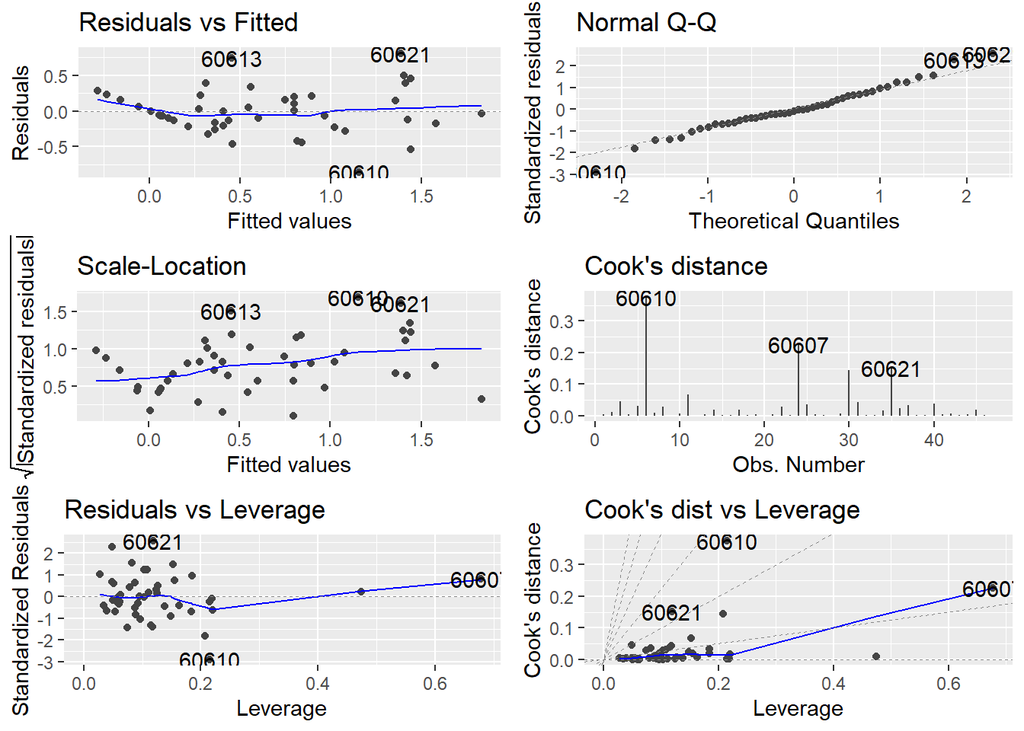

```r
autoplot(ch_lm, which = c(1:6))
```

적합한 모형 `ch_lm`을 기준으로 모형진단을 실시하였다.

먼저 잔차와 추정값 사이의 관계에서는 종속변수의 많은 0 값으로 인해 일부 streak이 관측되나 이를 제외하면 문제가 보이지 않으며, qqplot에서도 정규성에 큰 문제는 없는 것으로 보인다.

Influential data 확인을 위한 plot에서도 Cook’s distance 에서는 0.5를 넘는 수치는 나타나지 않으나, 모든 진단 plot에서 `60610`, `60607`, `60621` 세 데이터가 상대적으로 눈에 띄는 수치를 보이고 있음을 확인할 수 있다.

## Model diagnosis (2)

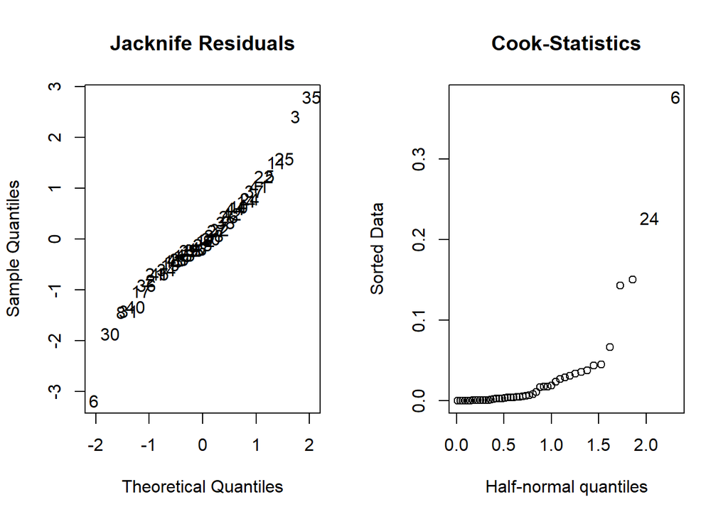

```r
# Diagnostic plots of Faraway
par(mfrow = c(1,2))
qqnorml(rstudent(ch_lm), main = "Jacknife Residuals")
halfnorm(cooks.distance(ch_lm), main = "Cook-Statistics")
```

```r
par(mfrow = c(1,1))
qt(0.05/(2*47),47-6-1)
```

```
## [1] -3.529468
```

Faraway에 따라 추가로 Jacknife Resifual 및 halfnorm plot을 통해 검토한 결과, 6번째 및 24번째 데이터인 `60610`, `60607`이 상대적으로 눈에 띄는 것을 재확인할 수 있다.

## Outliers? Influentials?

```r
# 해당 데이터 확인
kable(subset(chicago2, row.names(chicago2) %in% c(60610, 60607))) %>%
  kable_styling(bootstrap_options = c("striped", "hover"))
```

|  | race | fire | theft | age | involact | income |
| --- | --- | --- | --- | --- | --- | --- |
| 60610 | 54.0 | 34.1 | 68 | 52.6 | 0.3 | 8.231 |
| 60607 | 50.2 | 39.7 | 147 | 83.0 | 0.9 | 7.459 |

해당 데이터(`60610`, `60607`)를 확인한 결과, `fire`, `theft`가 높은 데이터로 기존의 회귀모형에 큰 영향을 주었을 수 있을 것이라 추정되는 바, 모형의 개선을 위하여 해당 Influention data 를 제외한 새로운 모형을 설계해 볼 필요가 있는 것으로 판단된다.

## Excluding influential data

```r
# 해당 데이터 제거
chicago3 <- subset(chicago2, !(row.names(chicago2) %in% c(60610, 60607)))

# 새로운 모형
ch_lm2 <- lm(involact ~ race + fire + theft + age + log(income),
            data = chicago3)
summary(ch_lm2)
```

```
##
## Call:
## lm(formula = involact ~ race + fire + theft + age + log(income),
##     data = chicago3)
##
## Residuals:
##      Min       1Q   Median       3Q      Max
## -0.63445 -0.21208 -0.02757  0.15580  0.83307
##
## Coefficients:
##              Estimate Std. Error t value Pr(>|t|)
## (Intercept) -0.576737   1.080046  -0.534   0.5964
## race         0.007053   0.002696   2.616   0.0126 *
## fire         0.049647   0.008570   5.793    1e-06 ***
## theft       -0.006434   0.004349  -1.479   0.1471
## age          0.005171   0.002895   1.786   0.0818 .
## log(income)  0.115703   0.401113   0.288   0.7745
## ---
## Signif. codes:  0 '***' 0.001 '**' 0.01 '*' 0.05 '.' 0.1 ' ' 1
##
## Residual standard error: 0.3032 on 39 degrees of freedom
## Multiple R-squared:  0.8041, Adjusted R-squared:  0.779
## F-statistic: 32.01 on 5 and 39 DF,  p-value: 8.192e-13
```

해당 관측치 두 건을 제외한 데이터셋 `chicago3`에 대해 새로운 모형을 적합하여 확인한 결과, 이전과 달리 `theft`와 `age`가 더 이상 유의수준 0.05에서 유의하지 않은 것으로 나타났다. 결정계수는 80% 수준으로 소폭 상승하였다.

## Transformation

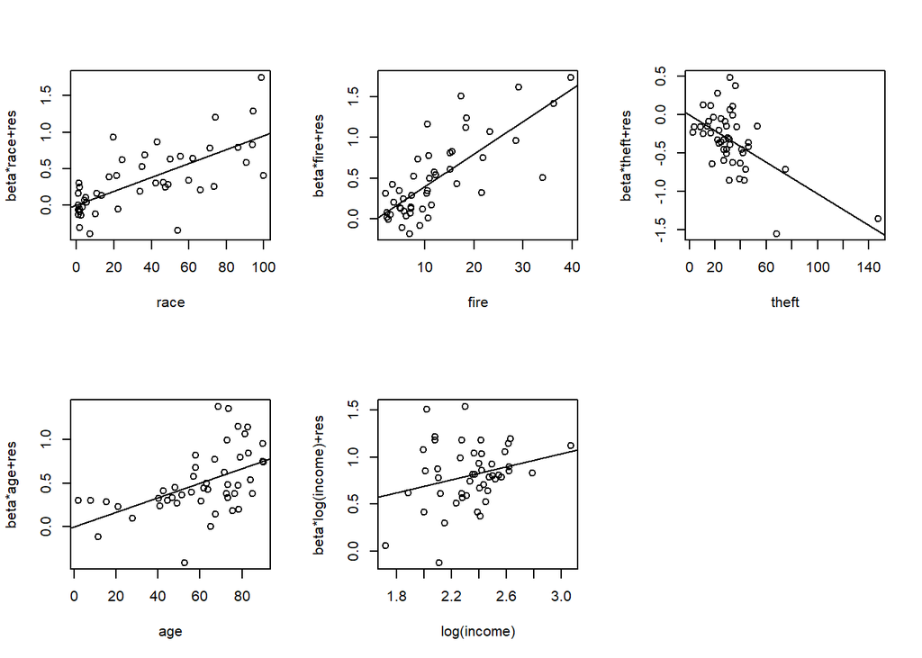

```r
# PR plots
par(mfrow = c(2, 3))
prplot(ch_lm, 1)
prplot(ch_lm, 2)
prplot(ch_lm, 3)
prplot(ch_lm, 4)
prplot(ch_lm, 5)
par(mfrow = c(1, 1))
```

```r
ch_lm3 <- lm(involact ~ race + poly(fire,2) + poly(theft,2) + poly(age,2) + poly(log(income),2),
             data = chicago3)
summary(ch_lm3)
```

```
##
## Call:
## lm(formula = involact ~ race + poly(fire, 2) + poly(theft, 2) +
##     poly(age, 2) + poly(log(income), 2), data = chicago3)
##
## Residuals:
##     Min      1Q  Median      3Q     Max
## -0.4861 -0.1603 -0.0080  0.1136  0.8378
##
## Coefficients:
##                        Estimate Std. Error t value Pr(>|t|)
## (Intercept)            0.432008   0.124001   3.484  0.00135 **
## race                   0.005363   0.003375   1.589  0.12105
## poly(fire, 2)1         3.057817   0.526075   5.813 1.36e-06 ***
## poly(fire, 2)2        -0.552471   0.404287  -1.367  0.18049
## poly(theft, 2)1       -0.402745   0.417335  -0.965  0.34115
## poly(theft, 2)2       -0.172566   0.440302  -0.392  0.69749
## poly(age, 2)1          0.249572   0.534504   0.467  0.64345
## poly(age, 2)2          0.136383   0.351284   0.388  0.70019
## poly(log(income), 2)1  0.142773   0.743264   0.192  0.84878
## poly(log(income), 2)2 -0.382691   0.429491  -0.891  0.37900
## ---
## Signif. codes:  0 '***' 0.001 '**' 0.01 '*' 0.05 '.' 0.1 ' ' 1
##
## Residual standard error: 0.3025 on 35 degrees of freedom
## Multiple R-squared:  0.8249, Adjusted R-squared:  0.7799
## F-statistic: 18.32 on 9 and 35 DF,  p-value: 8.879e-11
```

```r
anova(ch_lm2, ch_lm3)
```

```
## Analysis of Variance Table
##
## Model 1: involact ~ race + fire + theft + age + log(income)
## Model 2: involact ~ race + poly(fire, 2) + poly(theft, 2) + poly(age,
##     2) + poly(log(income), 2)
##   Res.Df    RSS Df Sum of Sq      F Pr(>F)
## 1     39 3.5853
## 2     35 3.2037  4   0.38165 1.0424 0.3994
```

Partial residual plot을 통해 확인한 결과 특별히 변수 변환의 필요성은 확인되지 않는다.

다만 실제 변환 필요성 여부를 검증하기 위하여 2차식까지의 변환을 검토하되, 종속변수와 `race`는 변수 변환 시 모형 해석상의 문제가 있음을 고려하여, 이들 두 변수는 제외한 2차식 모형 `ch_lm3`을 적합하였다.

## Variable Selection

```r
step(ch_lm2, direction = "both")
```

```
## Start:  AIC=-101.84
## involact ~ race + fire + theft + age + log(income)
##
##               Df Sum of Sq    RSS      AIC
## - log(income)  1   0.00765 3.5930 -103.746
## <none>                     3.5853 -101.841
## - theft        1   0.20119 3.7865 -101.385
## - age          1   0.29335 3.8787 -100.302
## - race         1   0.62912 4.2145  -96.566
## - fire         1   3.08521 6.6705  -75.903
##
## Step:  AIC=-103.75
## involact ~ race + fire + theft + age
##
##               Df Sum of Sq    RSS      AIC
## <none>                     3.5930 -103.746
## - theft        1    0.2181 3.8111 -103.094
## + log(income)  1    0.0076 3.5853 -101.841
## - age          1    0.3624 3.9554 -101.421
## - race         1    1.1208 4.7138  -93.527
## - fire         1    3.1943 6.7873  -77.122
```

```
##
## Call:
## lm(formula = involact ~ race + fire + theft + age, data = chicago3)
##
## Coefficients:
## (Intercept)         race         fire        theft          age
##   -0.267870     0.006489     0.049057    -0.005809     0.004688
```

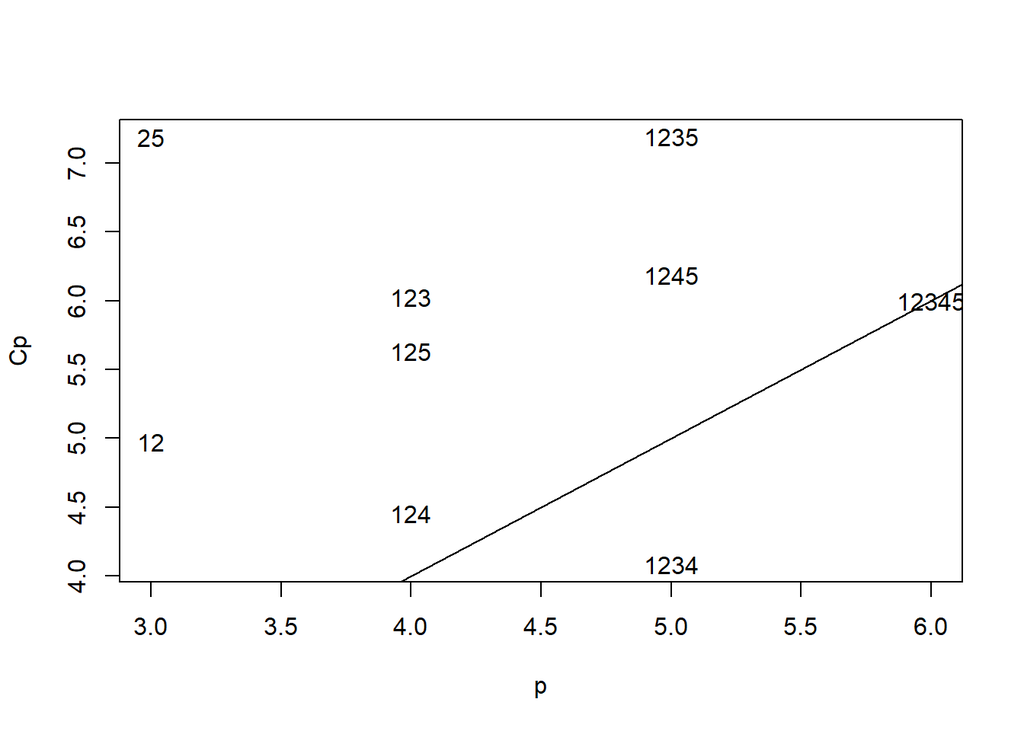

```r
y <- chicago3$involact
x <- cbind(chicago3[,1:4],linc = log(chicago3[,6]))
a <- leaps(x, y)
Cpplot(a)
```

`step` 문을 이용하여 AIC 기준으로 변수 선택을 진행한 결과, **`income`을 제외한 모형이 최적**으로 판별되었다.

Cp 값 기준으로 변수선택을 진행한 결과에서도, `income`을 제외한 **1234** 가 가장 낮은 Cp 값을 가지며 line에 근사하기에 최적의 조합인 것으로 판단된다.

## Final Model

```r
ch_lm4 <- lm(involact ~ race + fire + theft + age, data = chicago3)
summary(ch_lm4)
```

```
##
## Call:
## lm(formula = involact ~ race + fire + theft + age, data = chicago3)
##
## Residuals:
##     Min      1Q  Median      3Q     Max
## -0.6634 -0.2159 -0.0303  0.1665  0.8368
##
## Coefficients:
##              Estimate Std. Error t value Pr(>|t|)
## (Intercept) -0.267870   0.139668  -1.918  0.06228 .
## race         0.006489   0.001837   3.532  0.00105 **
## fire         0.049057   0.008226   5.963 5.32e-07 ***
## theft       -0.005809   0.003728  -1.558  0.12709
## age          0.004688   0.002334   2.009  0.05136 .
## ---
## Signif. codes:  0 '***' 0.001 '**' 0.01 '*' 0.05 '.' 0.1 ' ' 1
##
## Residual standard error: 0.2997 on 40 degrees of freedom
## Multiple R-squared:  0.8037, Adjusted R-squared:  0.784
## F-statistic: 40.93 on 4 and 40 DF,  p-value: 1.238e-13
```

변수선택 결과를 반영한 최종 모형을 확인한 결과, `race`와 `fire`가 유의수준 0.05에서 통계적으로 매우 유의하고, `theft`와 `age`는 유의하지 않은 것으로 나타났다. 결정계수는 80% 수준으로 양호하다.

분석 결과 `race`와 `involact` 사이에는 통계적으로 유의한 양의 상관관계가 있는 것으로 판단된다.

## Alternative Models

```r
summary(lm(involact ~ race + fire + log(income), data = chicago3))
```

```
##
## Call:
## lm(formula = involact ~ race + fire + log(income), data = chicago3)
##
## Residuals:
##      Min       1Q   Median       3Q      Max
## -0.75148 -0.19280 -0.00621  0.11072  0.87411
##
## Coefficients:
##              Estimate Std. Error t value Pr(>|t|)
## (Intercept)  0.753256   0.835880   0.901   0.3728
## race         0.004206   0.002276   1.848   0.0718 .
## fire         0.051022   0.008450   6.038 3.82e-07 ***
## log(income) -0.362382   0.319162  -1.135   0.2628
## ---
## Signif. codes:  0 '***' 0.001 '**' 0.01 '*' 0.05 '.' 0.1 ' ' 1
##
## Residual standard error: 0.3092 on 41 degrees of freedom
## Multiple R-squared:  0.7858, Adjusted R-squared:  0.7701
## F-statistic: 50.14 on 3 and 41 DF,  p-value: 8.873e-14
```

```r
summary(lm(involact ~ race + fire, data = chicago3))
```

```
##
## Call:
## lm(formula = involact ~ race + fire, data = chicago3)
##
## Residuals:
##      Min       1Q   Median       3Q      Max
## -0.65891 -0.20471 -0.01654  0.13807  0.87525
##
## Coefficients:
##              Estimate Std. Error t value Pr(>|t|)
## (Intercept) -0.191325   0.081517  -2.347  0.02371 *
## race         0.005712   0.001856   3.078  0.00366 **
## fire         0.054664   0.007845   6.968 1.61e-08 ***
## ---
## Signif. codes:  0 '***' 0.001 '**' 0.01 '*' 0.05 '.' 0.1 ' ' 1
##
## Residual standard error: 0.3103 on 42 degrees of freedom
## Multiple R-squared:  0.7791, Adjusted R-squared:  0.7686
## F-statistic: 74.05 on 2 and 42 DF,  p-value: 1.696e-14
```

```r
summary(lm(involact ~ race * log(income) + fire, data = chicago3))
```

```
##
## Call:
## lm(formula = involact ~ race * log(income) + fire, data = chicago3)
##
## Residuals:
##     Min      1Q  Median      3Q     Max
## -0.5321 -0.1424 -0.0203  0.1129  0.9408
##
## Coefficients:
##                   Estimate Std. Error t value Pr(>|t|)
## (Intercept)       1.406297   0.956221   1.471   0.1492
## race             -0.013468   0.013171  -1.022   0.3127
## log(income)      -0.633131   0.373239  -1.696   0.0976 .
## fire              0.051377   0.008368   6.140    3e-07 ***
## race:log(income)  0.007859   0.005771   1.362   0.1809
## ---
## Signif. codes:  0 '***' 0.001 '**' 0.01 '*' 0.05 '.' 0.1 ' ' 1
##
## Residual standard error: 0.306 on 40 degrees of freedom
## Multiple R-squared:  0.7953, Adjusted R-squared:  0.7748
## F-statistic: 38.85 on 4 and 40 DF,  p-value: 2.822e-13
```

유의하지 않은 두 변수를 제외하고 `log(income)`을 추가해본 결과, 오히려 `race`가 유의하지 않게 되었으며, 결정계수 또한 감소하였다. `log(income)`도 제외하고 `race`와 `fire`만 남겨본 결과에서는 다시 `race`가 유의하게 변한다. 이에 `race`와 `income` 간의 교호작용에 대한 검토를 실시해 보았으나 이 경우에서도 `fire`만이 유의한 것으로 나타났다.

## Diagnostics for Final Model

```r
vif(ch_lm4)
```

```
##     race     fire    theft      age
## 1.812106 2.033056 1.229193 1.386467
```

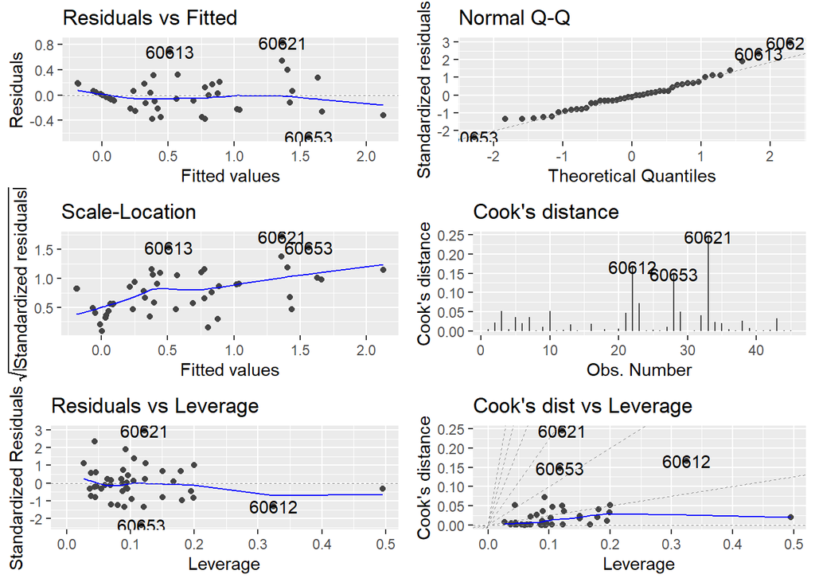

```r
autoplot(ch_lm4, which = c(1:6))
```

최종 모형에서 변수간의 다중공선성에 문제는 보이지 않으며, 모형 진단 Plot에서도 큰 이슈는 없는 것으로 판단된다.

## Further analysis for insight

```r
data("chiczip")
summary(lm(involact ~ race + fire + theft + age, subset=(chiczip == "s"), chicago))
```

```
##
## Call:
## lm(formula = involact ~ race + fire + theft + age, data = chicago,
##     subset = (chiczip == "s"))
##
## Residuals:
##      Min       1Q   Median       3Q      Max
## -0.62350 -0.17853 -0.03395  0.13479  0.87311
##
## Coefficients:
##              Estimate Std. Error t value Pr(>|t|)
## (Intercept) -0.234409   0.237741  -0.986   0.3380
## race         0.005949   0.003279   1.814   0.0873 .
## fire         0.048390   0.016886   2.866   0.0107 *
## theft       -0.006643   0.008444  -0.787   0.4423
## age          0.005008   0.005046   0.993   0.3348
## ---
## Signif. codes:  0 '***' 0.001 '**' 0.01 '*' 0.05 '.' 0.1 ' ' 1
##
## Residual standard error: 0.3508 on 17 degrees of freedom
## Multiple R-squared:  0.7434, Adjusted R-squared:  0.683
## F-statistic: 12.31 on 4 and 17 DF,  p-value: 6.969e-05
```

```r
summary(lm(involact ~ race + fire + theft + age, subset=(chiczip == "n"), chicago))
```

```
##
## Call:
## lm(formula = involact ~ race + fire + theft + age, data = chicago,
##     subset = (chiczip == "n"))
##
## Residuals:
##      Min       1Q   Median       3Q      Max
## -0.76422 -0.14994 -0.00813  0.15510  0.69974
##
## Coefficients:
##              Estimate Std. Error t value Pr(>|t|)
## (Intercept) -0.318573   0.227024  -1.403   0.1759
## race         0.012562   0.004478   2.806   0.0109 *
## fire         0.023129   0.013976   1.655   0.1135
## theft       -0.007582   0.003664  -2.069   0.0517 .
## age          0.008200   0.003461   2.369   0.0280 *
## ---
## Signif. codes:  0 '***' 0.001 '**' 0.01 '*' 0.05 '.' 0.1 ' ' 1
##
## Residual standard error: 0.3429 on 20 degrees of freedom
## Multiple R-squared:  0.7555, Adjusted R-squared:  0.7067
## F-statistic: 15.45 on 4 and 20 DF,  p-value: 6.519e-06
```

Faraway가 제공한 추가 자료 `chiczip`을 통해 남부/북부의 지역변수를 추가하여 모형을 적합한 결과, 지역을 구분하지 않았을 때와는 자못 다른 결과가 나타났다. 설명변수들의 유의성이 떨어졌으며, `race`의 영향력을 강조한 기존 결론과 달리 `race`는 북쪽지역에서만 유의한 모습을 보인다.

이처럼 기존에 생각하지 못하는 변수가 추가되거나 개별 데이터들이 모였을 때 분석결과가 변하는 것으로부터 언제나 완벽히 만족스러운 모델은 없다는 생각을 하게 된다. 주어진 상황에서 종합적인 고려를 통해 최선의 모형을 찾아내고 끊임없이 개선하려는 노력이 필요한 것으로 판단된다.